# Spring 2026 Project

Author

Theresa Louise Binnings

## Data Description

This data comes from the **National Science Foundation**, specifically the [*National Center for Science and Engineering Statistics*.](https://ncsesdata.nsf.gov/explorer/datatables) The data tables used were **nsf22310-tab001-005** (2019 survey data) and **nsf25322-tab001-005** (2023 survey data) - both titled “Employed scientists and engineers, by sex, major field of highest degree, ethnicity, race, disability status, and type of disability.”

The tables contain survey data capturing the count of employed individuals across generalized STEM fields, broken down by sex (male/female), race/ethnicity within each sex category, and disability status.

## Data Cleaning

The first 15 rows were skipped when reading in the Excel document from NSF; manual column labels were added. Skipping these rows bypassed the original row subheading format in the original Excel and excluded the section of data without Male/Female Sex classification. Non-zero count values marked with “*“,”D”, or “S” were converted to NA as the data was read in.

Since these visualizations centered on sex and race/ethnicity representation, columns related to disability representation were dropped. The original race/ethnicity labels that were spread across column headers were pivoted into a single “race/ethnicity” column with a parallel “count” column so that each count appeared as a distinct row.

A “sex” column was added to designate rows by male or female, eliminating the subheading structure within the first column of the original table.

The race/ethnicity column compiled categories with low counts — “American Indian or Alaska Native”, “Native Hawaiian or Other Pacific Islander”, and “Multiracial” — into a single “Other” category, allowing these counts to be visible in the final graphic relative to the larger groups of “Black or African American”, “Asian”, “Hispanic or Latino”, and “White”.

Finally, a proportion column was calculated and added to show the proportion of each race/ethnicity within each sex category relative to the total of all counts. A year column was added to each table and the two tables were joined to create the side-by-side bar chart comparison.

## Data Visualization 1

The charts also show a compounding underrepresentation: beyond the gender gap, Hispanic or Latino, Black or African American, and other racial and ethnic groups remain significantly underrepresented across all fields in both charts, with White employees making up the majority and Asian employees as the next largest group.

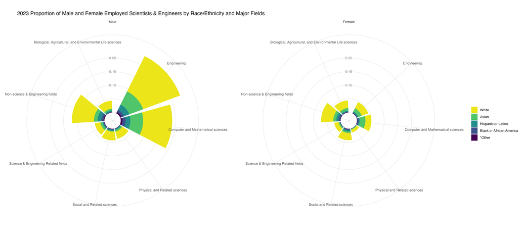

2023 proportion of employed scientists and engineers by race/ethnicity and major field, shown separately by sex (Male/Female). Source: National Science Foundation, National Center for Science and Engineering Statistics (nsf25322-tab001-005). *Other: *American Indian or Alaska Native*, *Native Hawaiian or Other Pacific Islander*, and *Multiracial*.

## Data Visualization 2

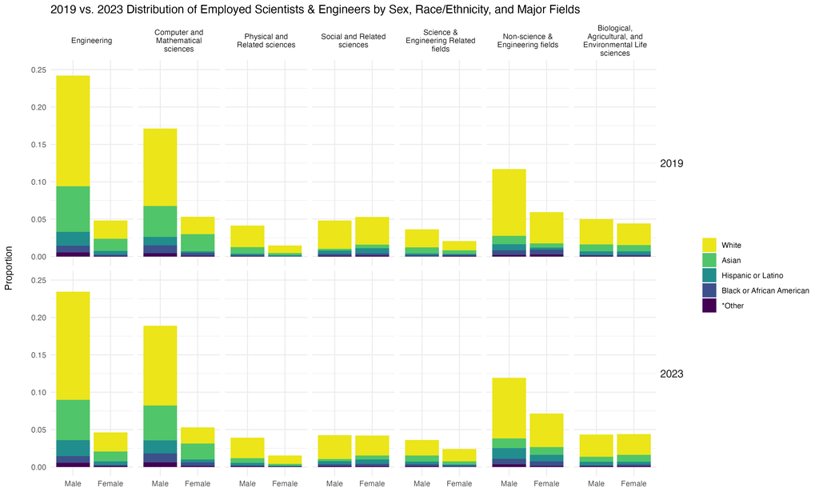

2019 vs. 2023 proportion of employed scientists and engineers by sex, race/ethnicity, and major field. Source: National Science Foundation, National Center for Science and Engineering Statistics (nsf22310-tab001-005; nsf25322-tab001-005). *Other: *American Indian or Alaska Native*, *Native Hawaiian or Other Pacific Islander*, and *Multiracial*

When one begins to look deeper at the history of science and recognize the advancements that have come as women entered the arena of science, it becomes clear that science advances dramatically with the incorporation of diverse backgrounds and perspectives. These charts showcase how we must still work to create diverse scientific arenas to foster greater exploration, advancement, and equity for all.